# Getting Started With preText

Matthew Denny

2016-09-25

This vignette is designed to introduce you to the **preText** R package.

The paper detailing the procedure can be found at the link below:

- Matthew J. Denny, and Arthur Spirling (2016). “Assessing the Consequences of Text Preprocessing Decisions”. [Not Yet Available]

## Installation

We are currently working on getting a version of the package up on CRAN. As soon as it is available, we will update the installation instructions.

If you want to get the latest version from GitHub, start by checking out the **Requirements for using C++ code with R** section in the following tutorial: [Using C++ and R code Together with Rcpp](http://www.mjdenny.com/Rcpp_Intro.html). You will likely need to install either `Xcode` or `Rtools` depending on whether you are using a Mac or Windows machine before you can install the preText package via GitHub, since it makes use of C++ code.

```r
install.packages("devtools")
```

Now we can install from Github using the following line:

```r
devtools::install_github("matthewjdenny/preText")
```

```r
library(preText)
```

If all went well, check out the `vignette("getting_started")` which will pull up this vignette!

## Basic Usage

```r
library(preText)
library(quanteda)

# load in U.S. presidential inaugural speeches from Quanteda example data.
corp <- corpus(inaugTexts)
# use first 10 documents for example
documents <- texts(corp)[1:10]
# take a look at the document names
print(names(documents))
```

```
##  [1] "1789-Washington" "1793-Washington" "1797-Adams"
##  [4] "1801-Jefferson"  "1805-Jefferson"  "1809-Madison"
##  [7] "1813-Madison"    "1817-Monroe"     "1821-Monroe"
## [10] "1825-Adams"
```

```r
preprocessed_documents <- factorial_preprocessing(
    documents,
    use_ngrams = TRUE,
    infrequent_term_threshold = 0.2,
    verbose = FALSE)
```

```
## Preprocessing 10 documents 128 different ways...
```

`##` This function will output a list object with three fields. The first of these is `$choices`, a data.frame containing indicators for each of the preprocessing steps used. The second is `$dfm_list`, which is a list with 64 or 128 entries, each of which contains a `quanteda::dfm` object preprocessed according to the specification in the corresponding row in `choices`. Each dfm in this list will be labeled to match the row names in choices, but you can also access these labels from the `$labels` field. We can look at the first few rows of `choices` below:

```r
names(preprocessed_documents)
```

```
## [1] "choices"  "dfm_list" "labels"
```

```r
head(preprocessed_documents$choices)
```

```
##               removePunctuation removeNumbers lowercase stem
## P-N-L-S-W-I-3              TRUE          TRUE      TRUE TRUE
## N-L-S-W-I-3               FALSE          TRUE      TRUE TRUE
## P-L-S-W-I-3                TRUE         FALSE      TRUE TRUE
## L-S-W-I-3                 FALSE         FALSE      TRUE TRUE
## P-N-S-W-I-3                TRUE          TRUE     FALSE TRUE
## N-S-W-I-3                 FALSE          TRUE     FALSE TRUE
##               removeStopwords infrequent_terms use_ngrams
## P-N-L-S-W-I-3            TRUE             TRUE       TRUE
## N-L-S-W-I-3              TRUE             TRUE       TRUE
## P-L-S-W-I-3              TRUE             TRUE       TRUE
## L-S-W-I-3                TRUE             TRUE       TRUE
## P-N-S-W-I-3              TRUE             TRUE       TRUE
## N-S-W-I-3                TRUE             TRUE       TRUE
```

Now that we have our preprocessed documents, we can perform the preText procedure on the factorial preprocessed corpus using the `preText()` function. It will be useful now to give a name to our data set using the `dataset_name` argument, as this will show up in some of the plots we generate with the output. The standard number of pairs to compare is 50 for reasonably sized corpora, but because we are only using 10 documents, the maximum number of pairwise document distances is only (10)*(10 - 1)/2 = 45, so we select 20 pairwise comparisons for purposes of illustration. This function will usually not take as long to run as the `factorial_preprocessing()` function, but parallelization is also available for this function if a speedup is desired. It is suggested that the user select `verbose = TRUE` in practice, but we set it to FALSE here to avoid cluttering this vignette. This function should run in 10-30 seconds for this small corpora, and in several hours to a day for most moderately sized corpora.

```r
preText_results <- preText(
    preprocessed_documents,
    dataset_name = "Inaugural Speeches",
    distance_method = "cosine",
    num_comparisons = 20,
    verbose = FALSE)
```

```
## Generating document distances...
## Generating preText Scores...
## Generating regression results..
## Regression results (negative coefficients imply less risk):
##                  Variable Coefficient    SE
## 1               Intercept       0.117 0.004
## 2      Remove Punctuation       0.020 0.003
## 3          Remove Numbers       0.001 0.003
## 4               Lowercase      -0.010 0.003
## 5                Stemming      -0.004 0.003
## 6        Remove Stopwords      -0.022 0.003
## 7 Remove Infrequent Terms       0.000 0.003
## 8              Use NGrams      -0.028 0.003
## Complete in: 12.292 seconds...
```

The `preText()` function returns a list of result with four fields:

- `$preText_scores`: A data.frame containing preText scores and preprocessing step labels for each preprocessing step as columns. Note that there is no preText score for the case of no prepprocessing steps.
- `$ranked_preText_scores`: A data.frame that is identical to `$preText_scores` except that it is ordered by the magnitude of the preText score
- `$choices`: A data.frame containing binary indicators of which preprocessing steps were applied to factorial preprocessed dfm.
- `$regression_results`: A data.frame containing regression results where indicators for each preprocessing decision are regressed on the preText score for that specification.

We can now feed these results to two functions that will help us make better sense of them. `preText_score_plot()` creates a dot plot of scores for each preprocessing specification:

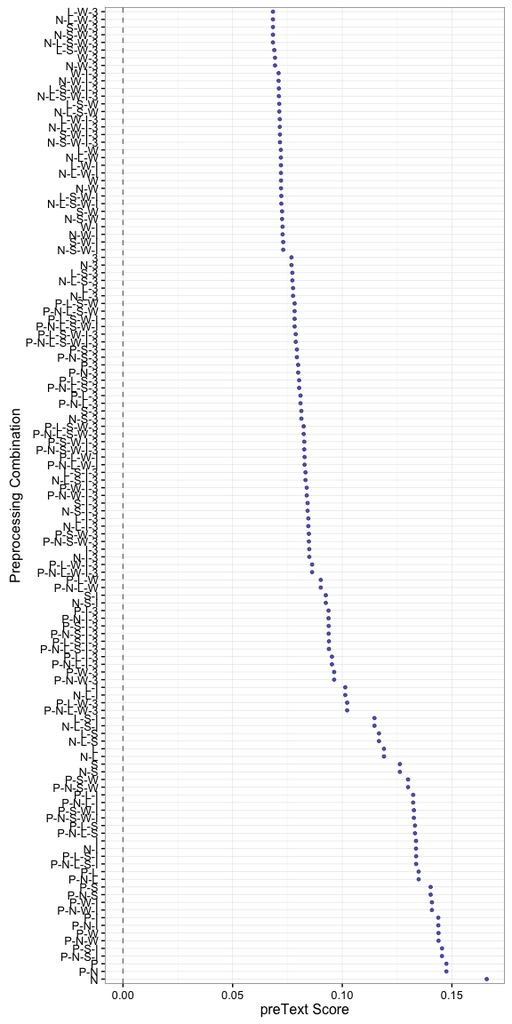

```r
preText_score_plot(preText_results)
```

Here, the least risky specifications have the lowest preText score and are displayed at the top of the plot. We can also see the conditional effects of each preprocessing step on the mean preText score for each specification that included that step. Here again, a negative coefficient indicates that a step tends to reduce the unusualness of the results, while a positive coefficient indicates that applying the step is likely to produce more unusual results for that corpus.

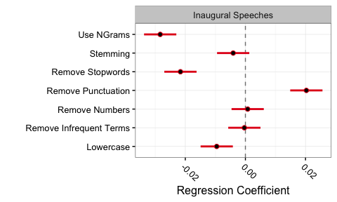

```r
regression_coefficient_plot(preText_results,
                            remove_intercept = TRUE)
```